# Austbygdåi

Author

Emmanuel Jjunju

[output not shown]

Emmanuel Jjunju

# 1 Innledning

Trond Reitan (NVE) har utviklet R‑skripter som gjør det mulig å kjøre **Full Lokal + Regional Analyse** direkte i R.  
Skriptene er nyttige både når man ikke har tilgang til NVEs flomanalyseprogram  
(https://www.nve.no/media/16334/flood_analysis.pdf), og når man ønsker å jobbe i R og eventuelt i en notatbok.

## 1.1 Kjerneskripter for full lokal og regional analyse

Hovedlogikken for analysen ligger i følgende skripter:

- **`mcmc.R`**  
  Kjører en Bayesiansk MCMC‑algoritme som tester mange mulige parameterverdier, beholder de som passer best, og bruker resultatene til å sammenligne modeller.
- **`full_local_regional.R`**  
  Forutsetter at `mcmc.R` allerede er kjørt. Skriptet innedolder funskjoner som leser inn klima- og flomdata, estimerer GEV‑parametere ved hjelp av regionale klimarelasjoner og Bayesiansk MCMC, og beregner samt plotter flomstørrelser og usikkerhet (returverdier).
- Prior og likelihood er definert i disse filene.

## 1.2 Enkelt eksempel

Følgende funksjonalitet er inkludert i `example_full_local_regional.R`:

- Kvantil‑tabell
- Plotting av flomkurve
- Plotting av MCMC‑sampler (for spesielt interesserte)

## 1.3 Formålet med dette notatet

Dette notatet viser et tilpasset eksempel på hvordan skriptene brukes for **én stasjon**.  
Notatet gir også mulighet til å sammenligne resultatene med beregninger gjort i flomanalyseprogrammet i Hydra2.

Notatet er laget av Emmanuel Jjunju (NVE). I tillegg til skriptene fra Trond Reitan er det lagt til egne R‑funksjoner (`custom_functions.r`) for blant annet dataimport (fra Sildre m.m.) og plotting.

## 1.4 Merk

Full lokal + RFFA‑2018 er ikke utviklet for findata. Derfor må flomfrekvensanalyse på findata gjøres som **lokal flomfrekvensanalyse**.

Hvis du har 10–25 år med findata for feltstørrelse > 60 km², antar vi at du også har en lengre tidsserie med døgndata.  
I slike tilfeller anbefaler vi at du bruker døgndataene i analysene.

Hvis du har like lange tidsserier for døgn- og findata, bør du gjennomføre flomfrekvensanalyse på begge og deretter vurdere hvilke estimater som fremstår mest sannsynlige.

Setup (R) # Pakker og r-skripter

**✅ Enter paths to your R Scripts**

```r
path.to.rscripts<-"N:/EJJ/R_FFA_FullLokal_RegionalAnalyse/01_R_Scripts"
```

```r
# Kjerneskripter fra Trond reitan
source(file = paste0(path.to.rscripts,"/","mcmc.R")) # # Get MCMC motor
source(file = paste0(path.to.rscripts,"/","full_local_regional.r"))
# custom functions (Emmanuel Jjunju)
# #tilpaset funskosner for plotting osv ,også laster opp andre nødvendinge pakker
source(file = paste0(path.to.rscripts,"/","custom_functions.r") )
#options
options(repr.plot.width = 12, repr.plot.height = 4) #set figure heights and widths
options( #Set global widget size for the whole notebook
    htmlwidgets.defaultWidth = "1200px",
    htmlwidgets.defaultHeight = "1200px"
)
```

# 2 Mapper

## 2.1 Hovedmappe

i hoved mappen finnes følgende nødvendinge filer og mapper

1. **Dette Notatet `Run_R_FL_RFFA.ipynb` som entry point to analysen**
2. **`01_R_Scripts` mappe inneholder skripter som er nevnt tidligere**
   - `mcmc.R`
   - `full_local_regional.r`
   - `example_full_local_regional.R` : eksepel for en enkel kjøring (brukt som veiledning)
   - `custom_functions.r`
3. **`02_Beregninger`**
   - Lagre *Stasjonsmapper* in denne mappen
   - Mappen `02_Beregninger` kan inneholde mange `Stasjonsmmapper` men `Stajonsmmape` med stien i `path_to_station_folder.csv`

## 2.2 Stasjonsmappe (project.dir)

1. Stasjonsmappe bør inneholde input‑filene for én stasjon.**
2. **Filene kan plasseres i intuitivt navngitte mapper som gjenspeiler kilde og innhold.**
   - AMS (årsmaksimal) : inneholder filer med årsmaksimal
   - FLOMANALYSE : inneholder csv filer eksportert fra hydra2/Flomanalyse
   - NEVINA : inneholder filer eksporert fra NEVINA (viktihste filen er shapefil med felt og klimaparametre)
   - SILDRE : Inneholder filer eksportert fra Sildre
3. **De nødvendige filstiene er spesifisert i en CSV‑fil (`file.paths.csv`) som må ligge i `Stasjonsmappe`.**
   - Redigere denne med stiene til filene for ditt prosjekt. bruk en ny mappe for hver stasjon.
   - Stiene i `file.paths.csv` skal være relative til`Stasjonsmappe`. Se eksempel i `02_Beregninger/Austbygdåi/file.paths.csv`.
   - Obs!! Skripten legger til stien til `Stasjonsmappe` feks hvis man skriver stien `Sildre/16.128.0-Vannføring-time-v1.csv så vil skripten` , det endres til `N:/EJJ/R_FFA_FullLokal_RegionalAnalyse/02_Beregninger/Austbygdåi/Sildre/16.128.0-Vannføring-time-v1.csv` hvis `Stasjonsmappe` er `N:/EJJ/R_FFA_FullLokal_RegionalAnalyse/02_Beregninger/Austbygdåi`
4. **Sett stien til `Stasjonsmappe`.**
   - Med `Stasjonsmappe` menes mappen som inneholder filer for en-stasjon som skal analyseres
   - `Stasjonsmappe` må lagres i mappen `02_Beregninger`.
   - Vi analyserer én stasjon om gangen. Vi lager derfor en egen prosjektmappe for hver stasjon under mappen `02_Bergninger`.
   - Angi stien til din `Stasjonsmappe` manuelt ved å redigere nedenfor

**✅ Enter path to your station folder (Stasjonsmappe)**

project.dir<-“REPLACE HERE”

```r
project.dir<-"N:/EJJ/R_FFA_FullLokal_RegionalAnalyse/02_Beregninger/Austbygdåi" #Stasjonsmappe
project.name<-unlist(strsplit(project.dir,"\\/"))
print(project.name<-project.name[length(project.name)])
```

```
[1] "Austbygdåi"
```

```r
print(project.dir)
```

```
[1] "N:/EJJ/R_FFA_FullLokal_RegionalAnalyse/02_Beregninger/Austbygdåi"
```

## 2.3 Paths to files

```r
file.paths<-paste0(project.dir,"/file.paths.csv")
print(file.paths)
```

```
[1] "N:/EJJ/R_FFA_FullLokal_RegionalAnalyse/02_Beregninger/Austbygdåi/file.paths.csv"
```

```r
DT::datatable(t(data.frame(project.dir,file.paths)))
```

|  | V1 |
| --- | --- |
| project.dir | N:/EJJ/R_FFA_FullLokal_RegionalAnalyse/02_Beregninger/Austbygdåi |
| file.paths | N:/EJJ/R_FFA_FullLokal_RegionalAnalyse/02_Beregninger/Austbygdåi/file.paths.csv |

```r
# Read input.paths.csv file
input.paths<-read.csv(file.paths)
input.paths$path<-paste0(project.dir,"/",input.paths$path)
DT::datatable(
  input.paths,
  caption = "Scenarios",
  options = list(
    dom = "tp",
    autoWidth = TRUE  )
) %>%
  htmlwidgets::onRender(
    sprintf("function(el,x){$('table.dataTable').css('font-size','%spx');}", 12)
  )
```

|  | var | path | status | type | comment |
| --- | --- | --- | --- | --- | --- |
| 1 | sildre.timesverdier.txt | N:/EJJ/R_FFA_FullLokal_RegionalAnalyse/02_Beregninger/Austbygdåi/Sildre/16.128.0-Vannføring-time-v1.csv | Input | timeseries | Sildre Timesverdier |
| 2 | sildre.døgnverdier.txt | N:/EJJ/R_FFA_FullLokal_RegionalAnalyse/02_Beregninger/Austbygdåi/Sildre/16.128.0-Vannføring-dogn-v1.csv | Input | timeseries | Sildre døgnverdier |
| 3 | nevina.shp | N:/EJJ/R_FFA_FullLokal_RegionalAnalyse/02_Beregninger/Austbygdåi/NEVINA/zipfolder/NedbfeltF_v4.shp | Input | Shapefile | Nedbørfelt shapefil fra NEVINA |
| 4 | flomanalyse.quantiles.6190 | N:/EJJ/R_FFA_FullLokal_RegionalAnalyse/02_Beregninger/Austbygdåi/FLOMANALYSE/Austbygdåi Flomanalyse quantiles 6190.txt | Input(optional) | Quantiles | Result of FFA in flomanalyse 1961-1990 params(for comparing) |
| 5 | flomanalyse.quantiles.9120 | N:/EJJ/R_FFA_FullLokal_RegionalAnalyse/02_Beregninger/Austbygdåi/FLOMANALYSE/Austbygdåi Flomanalyse quantiles 9120.txt | Input(optional) | Quantiles | Result of FFA in flomanalyse 1991-2020 params(for comparing) |
| 6 | hydra2.finut.quantiles.Qmom | N:/EJJ/R_FFA_FullLokal_RegionalAnalyse/02_Beregninger/Austbygdåi/FLOMANALYSE/Austbygdåi hydra2.finut.quantiles.txt | Input(optional) | Quantiles | Result of FFA in hydra2.finut(for comparing) |
| 7 | ams.sildre.Qmom.short | N:/EJJ/R_FFA_FullLokal_RegionalAnalyse/02_Beregninger/Austbygdåi/AMS/ams.sildre.qmom.fra.timesverdier.txt | Processed | AMS | (årsmaksimal Qmom) from timesverdier |
| 8 | ams.sildre.Qdogn.short | N:/EJJ/R_FFA_FullLokal_RegionalAnalyse/02_Beregninger/Austbygdåi/AMS/ams.sildre.qdogn.fra.timesverdier.txt | Processed | AMS | (årsmaksimal Qdogn) from timesverdier |
| 9 | ams.sildre.Qdogn.long | N:/EJJ/R_FFA_FullLokal_RegionalAnalyse/02_Beregninger/Austbygdåi/AMS/ams.sildre.qdøgn.fra.døgnverdier.txt | Processed | AMS | (årsmaksimal Qdøgn) from døgnverdier |
| 10 | params6190 | N:/EJJ/R_FFA_FullLokal_RegionalAnalyse/02_Beregninger/Austbygdåi/NEVINA/Austbygdåi_klima6190.csv | Processed | klimafile | for 1961-1990 |

[output cut: 1 more lines]

```r
n<-nrow(input.paths)
eval(parse(text=paste(input.paths$var,"<-input.paths$path[",1:n,"]")))
```

## 2.4 Computation scenarios

```r
#dognverdier
#-------------------------------------------------------------------------------------------
ams.dogn.file.list<-list(ams.sildre.Qdogn.long =ams.sildre.Qdogn.long)
#kulminasjons
#-------------------------------------------------------------------------------------------
ams.mom.file.list<-list(ams.sildre.Qmom.short= ams.sildre.Qmom.short) # not used in FFA + lokal
# Klimafile
#-------------------------------------------------------------------------------------------
klima.file.list<-list(params6190=params6190,params9120 =params9120)

# Create Scenarios form all combinations
#-------------------------------------------------------------------------------------------
scenarios.df <- expand.grid(
  ams   = names(ams.dogn.file.list),
  klima = names(klima.file.list),
  stringsAsFactors = FALSE
)

# Add file paths
#-------------------------------------------------------------------------------------------
scenarios.df$ams_path   <- unlist(ams.dogn.file.list[scenarios.df$ams])
scenarios.df$klima_path <- unlist(klima.file.list[scenarios.df$klima])

# Add new.reg.coef column
#-------------------------------------------------------------------------------------------
scenarios.df$new.reg.coef <- scenarios.df$klima != "params6190"

#add auto scenario name
#-------------------------------------------------------------------------------------------
scenarios.df<-scenarios.df[order(scenarios.df$ams),]
scenario<-paste0(scenarios.df$ams,"_",scenarios.df$klima)
scenarios.df<-cbind(scenario,scenarios.df[,-c(1:2)])

# Show scenarios table
#-------------------------------------------------------------------------------------------
scenarios.df<-scenarios.df[order(scenarios.df$ams),]
fx.compact_dt( scenarios.df, caption = "Scenarios", fontsize = 12 )
```

**Scenarios**

|  | scenario | ams_path | klima_path | new.reg.coef |
| --- | --- | --- | --- | --- |
| 1 | ams.sildre.Qdogn.long_params6190 | N:/EJJ/R_FFA_FullLokal_RegionalAnalyse/02_Beregninger/Austbygdåi/AMS/ams.sildre.qdøgn.fra.døgnverdier.txt | N:/EJJ/R_FFA_FullLokal_RegionalAnalyse/02_Beregninger/Austbygdåi/NEVINA/Austbygdåi_klima6190.csv | False |
| 2 | ams.sildre.Qdogn.long_params9120 | N:/EJJ/R_FFA_FullLokal_RegionalAnalyse/02_Beregninger/Austbygdåi/AMS/ams.sildre.qdøgn.fra.døgnverdier.txt | N:/EJJ/R_FFA_FullLokal_RegionalAnalyse/02_Beregninger/Austbygdåi/NEVINA/Austbygdåi_klima9120.csv | True |

# 3 AMS (Sildre timesverdier)

- Inneholder én AMS (årsmaksimal) av tidsserier per linje.

## 3.1 Sildre (timesverdier) => ams.[qdøgn & qmom]

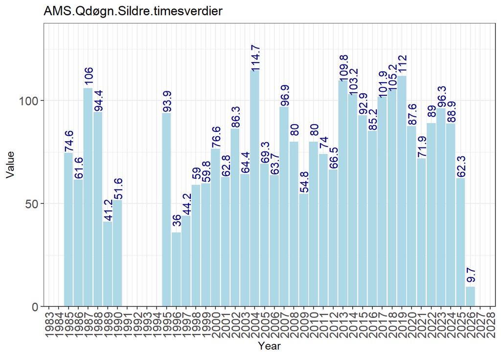

```r
ams2<-fx.sildre.timeseries.to.ams (file=sildre.timesverdier.txt,
                                   sep = ";",
                                   ams.qdogn.txt=ams.sildre.Qdogn.short,
                                   ams.qmom.txt=ams.sildre.Qmom.short,
                                   plot = TRUE,
                                   title="Sildre.timesverdier",
                                   fontsize=12
                                  )
#Qdøgn
#ams2$daily_mean$DT
ams2$daily_mean$plot
```

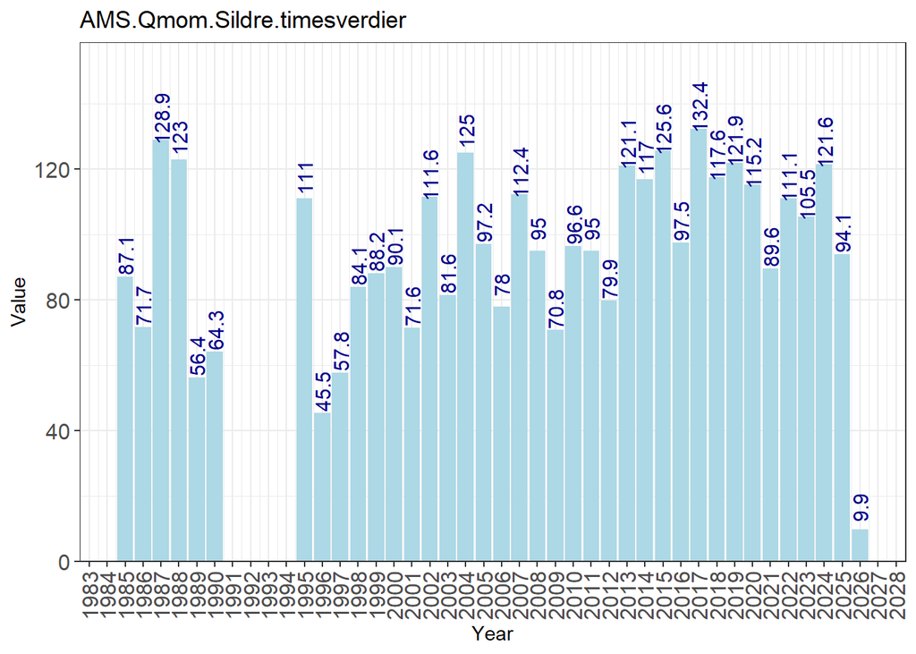

```r
# Qmom
#ams2$daily_max$DT
ams2$daily_max$plot
```

## 3.2 Sildre (Forholdstall = Qmom / Qdøgn)

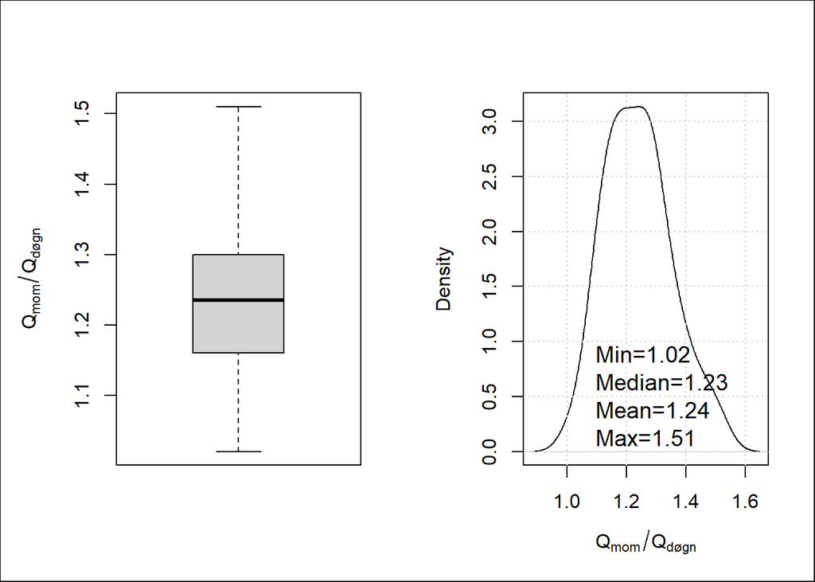

```r
# forholdstall = Qmom / Qdøgn
forholdstall <- round(ams2$daily_max$ams$value / ams2$daily_mean$ams$value, 2)
# Clean summary
s <- summary(forholdstall)
sm <- data.frame(
  stat  = c("Min", "Median", "Mean", "Max"),
  value = round(c(s["Min."], s["Median"],s["Mean"],s["Max."]  ), 2))
# ---- MAIN PLOT ----
par(mar = c(5,5,4,2),mfrow=c(1,2))
boxplot(forholdstall, ylab =expression(Q[mom] / Q[døgn]))
plot(density(forholdstall),main="",xlab = expression(Q[mom] / Q[døgn]));grid()
txt<-paste(apply(sm,1,function(x) paste(x,collapse="=")))
legend("bottom", txt,bty="n",cex=1.2);    box(which  ="outer")
```

## 3.3 Sildre (døgnverdier) => ams.qdøgn (usually longer)

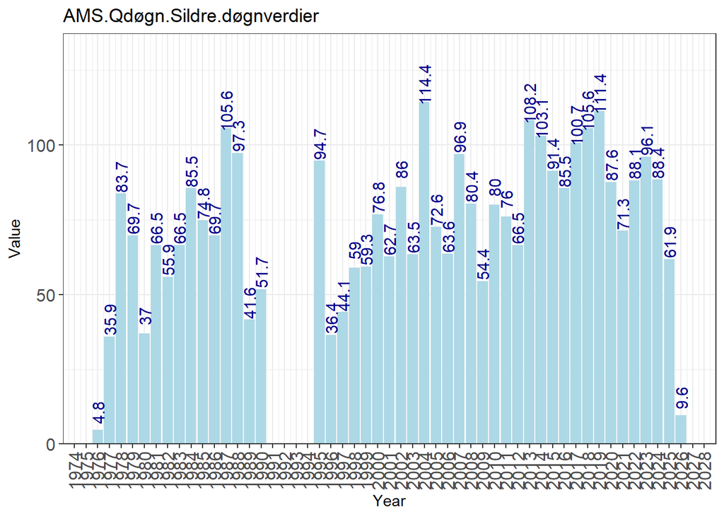

```r
ams3<-fx.sildre.timeseries.to.ams (file=sildre.døgnverdier.txt, sep = ";",
                                   ams.qdogn.txt =ams.sildre.Qdogn.long,
                                   ams.qmom.txt=NA,
                                   plot = TRUE,
                                   title="Sildre.døgnverdier",
                                   fontsize=12)
#ams3$daily_mean$DT
ams3$daily_mean$plot
```

# 4 Klimavariabel-fil

- Eksempel: `farstad_clim.csv`
- Inneholder flere klima- og feltvariabler.
  - area.km2
  - avr.specific.discharge
  - eff.lake.perc
  - river.length.main.km
  - temp.feb.celcius
  - temp.mar.celcius
  - precip.melt.may
  - glacier.perc
  - forest.perc
  - hypso.height.10perc
  - precipitation.july
  - sum.precip.melt.june
  - total.river.length.without.lakes.all.km
- Verdier kan hentes fra:
  - NEVINA
  - Hydra2-databasen
  - FLOM_ANALYSE → *Editer regionale feltvariabler* (for å inspisere tallene)

```r
# read from shp downlaoded from NEVINA
prm <- fx.extract.klima.from.shp(
    shpfile = nevina.shp,
    params6190 = params6190,
    params9120 = params9120,
    plot.map = TRUE,
    map.width="900px",
    map.height="500px"
)
prm$map
```

[interactive chart not shown]

**Klima (1961–1990 vs 1991–2020)**

| Variable | 1961–1990 | 1991–2020 |
| --- | --- | --- |
| area.km2 | 342.30 | 342.30 |
| avr.specific.discharge | 25.50 | 21.90 |
| eff.lake.perc | 0.10 | 0.10 |
| river.length.main.km | 47.70 | 47.70 |
| temp.feb.celcius | -9.30 | -7.71 |
| temp.mar.celcius | -7.20 | -5.74 |
| precip.melt.may | 281.40 | 351.72 |
| glacier.perc | 0.00 | 0.00 |
| forest.perc | 33.20 | 33.20 |
| hypso.height.10perc | 821.00 | 821.00 |
| precipitation.july | 84.60 | 100.15 |
| sum.precip.melt.june | 138.20 | 172.69 |
| total.river.length.without.lakes.all.km | 532.90 | 532.90 |

# 5 Run FFA (Fulllokal + Regional - AMS døgnverdier)

## 5.1 Helper fnction to call `perform.analysis` for several scenarios

```r
# print(scenarios.df)
 run.FullLokalRFFA.scenarios <- function(scenarios.df,plot.curve=FALSE) {
     options(repr.plot.width = 12, repr.plot.height = 10) #set figure heights and widths
  out <- list()
  for (i in seq_len(nrow(scenarios.df))) {
      sc <- scenarios.df[i, ]
      print("-----------------------------------------------------------------------------------------------------------------")
      print(paste("Scenario",i))
      print(paste0(names(sc)," = ",sc[])) #SCENARIO
      #TROND's function called here
      res <- perform.analysis(
          sc$ams_path, #AMSFILE
          sc$klima_path, #KLIMAFILE
          new.reg.coef = sc$new.reg.coef
      )

      #str(res)
      tbl <- quantile.summary(
          c(0,2,5,10,20,50,100,200,500,1000),
          res
      )
      #print(tbl)
      tbl <- as.data.frame(lapply(tbl, function(x)
          if (is.numeric(x)) round(x, 2) else x))
              tbl$Relative<-round(tbl$Post.mean/tbl$Post.mean[1],3)

     #output res and quantile table
     out[[sc$scenario]] <- list(
              table = tbl,
              analysis = res
          )
    #plot.res.mcmc(res,main=scenarios.df$scenario[i])
    if(plot.curve){#plot curves if only 2 scenarios
     if(i==1){
         plot.quantile.curve.base(analysis = res,add = FALSE, show.pp.uncertainty = TRUE,label =scenarios.df$scenario[i] )
     } else {
         plot.quantile.curve.base(analysis = res,add = TRUE, show.pp.uncertainty = TRUE,label =scenarios.df$scenario[i])
         }
        }

  }
  out
}
```

## 5.2 Run all scenarios (based on Sildre data)

**⚠️ If an Error Occurs (Usually on first run)**

“Error in if (mu + exp(ls)/k * ((log(2)^(-k) - 1)) <= 0) return(-1e+200): missing value where TRUE/FALSE needed”

**I Simply rerun the function — it will eventually complete successfully. (consult Trond Reitan)**

```r
#results <- run.FullLokalRFFA.scenarios(scenarios.df) #
# sometmes fails so thisisnmy workaround
results <- NULL
max_attempts <- 10
attempt <- 1

repeat {
  results <- tryCatch({
    run.FullLokalRFFA.scenarios(scenarios.df) # Your function
  }, error = function(e) {
    message(paste("Attempt", attempt, "failed:", e$message))
    return(NULL) # Return NULL to signal failure to the loop
  })

  if (!is.null(results)) {
    message("FFA run successfully!")
    break # Success, break the loop
  }

  attempt <- attempt + 1
  if (attempt > max_attempts) {
    stop("Maximum attempts reached. Function still failing.")
  }
  Sys.sleep(2) # Optional: Wait 2 seconds before retrying
}
```

```
[1] "-----------------------------------------------------------------------------------------------------------------"
[1] "Scenario 1"
[1] "scenario = ams.sildre.Qdogn.long_params6190"
[2] "ams_path = N:/EJJ/R_FFA_FullLokal_RegionalAnalyse/02_Beregninger/Austbygdåi/AMS/ams.sildre.qdøgn.fra.døgnverdier.txt"
[3] "klima_path = N:/EJJ/R_FFA_FullLokal_RegionalAnalyse/02_Beregninger/Austbygdåi/NEVINA/Austbygdåi_klima6190.csv"
[4] "new.reg.coef = FALSE"
[1] "-----------------------------------------------------------------------------------------------------------------"
[1] "Scenario 2"
[1] "scenario = ams.sildre.Qdogn.long_params9120"
[2] "ams_path = N:/EJJ/R_FFA_FullLokal_RegionalAnalyse/02_Beregninger/Austbygdåi/AMS/ams.sildre.qdøgn.fra.døgnverdier.txt"
[3] "klima_path = N:/EJJ/R_FFA_FullLokal_RegionalAnalyse/02_Beregninger/Austbygdåi/NEVINA/Austbygdåi_klima9120.csv"
[4] "new.reg.coef = TRUE"
```

```
Attempt 1 failed: missing value where TRUE/FALSE needed
```

```
[1] "-----------------------------------------------------------------------------------------------------------------"
[1] "Scenario 1"
[1] "scenario = ams.sildre.Qdogn.long_params6190"
[2] "ams_path = N:/EJJ/R_FFA_FullLokal_RegionalAnalyse/02_Beregninger/Austbygdåi/AMS/ams.sildre.qdøgn.fra.døgnverdier.txt"
[3] "klima_path = N:/EJJ/R_FFA_FullLokal_RegionalAnalyse/02_Beregninger/Austbygdåi/NEVINA/Austbygdåi_klima6190.csv"
[4] "new.reg.coef = FALSE"
[1] "-----------------------------------------------------------------------------------------------------------------"
[1] "Scenario 2"
[1] "scenario = ams.sildre.Qdogn.long_params9120"
[2] "ams_path = N:/EJJ/R_FFA_FullLokal_RegionalAnalyse/02_Beregninger/Austbygdåi/AMS/ams.sildre.qdøgn.fra.døgnverdier.txt"
[3] "klima_path = N:/EJJ/R_FFA_FullLokal_RegionalAnalyse/02_Beregninger/Austbygdåi/NEVINA/Austbygdåi_klima9120.csv"
[4] "new.reg.coef = TRUE"
```

```
Attempt 2 failed: missing value where TRUE/FALSE needed
```

```
[1] "-----------------------------------------------------------------------------------------------------------------"
[1] "Scenario 1"
[1] "scenario = ams.sildre.Qdogn.long_params6190"
[2] "ams_path = N:/EJJ/R_FFA_FullLokal_RegionalAnalyse/02_Beregninger/Austbygdåi/AMS/ams.sildre.qdøgn.fra.døgnverdier.txt"
[3] "klima_path = N:/EJJ/R_FFA_FullLokal_RegionalAnalyse/02_Beregninger/Austbygdåi/NEVINA/Austbygdåi_klima6190.csv"
[4] "new.reg.coef = FALSE"
```

```
Attempt 3 failed: missing value where TRUE/FALSE needed
```

```
[1] "-----------------------------------------------------------------------------------------------------------------"
[1] "Scenario 1"
[1] "scenario = ams.sildre.Qdogn.long_params6190"
[2] "ams_path = N:/EJJ/R_FFA_FullLokal_RegionalAnalyse/02_Beregninger/Austbygdåi/AMS/ams.sildre.qdøgn.fra.døgnverdier.txt"
[3] "klima_path = N:/EJJ/R_FFA_FullLokal_RegionalAnalyse/02_Beregninger/Austbygdåi/NEVINA/Austbygdåi_klima6190.csv"
[4] "new.reg.coef = FALSE"
[1] "-----------------------------------------------------------------------------------------------------------------"
[1] "Scenario 2"
[1] "scenario = ams.sildre.Qdogn.long_params9120"
[2] "ams_path = N:/EJJ/R_FFA_FullLokal_RegionalAnalyse/02_Beregninger/Austbygdåi/AMS/ams.sildre.qdøgn.fra.døgnverdier.txt"
[3] "klima_path = N:/EJJ/R_FFA_FullLokal_RegionalAnalyse/02_Beregninger/Austbygdåi/NEVINA/Austbygdåi_klima9120.csv"
[4] "new.reg.coef = TRUE"
```

```
FFA run successfully!
```

```r
#str(results,3)
analyses<-lapply(results,function(x) x$analysis)
#str(analyses,3)
```

```r
#plot quantile tables from the ananlysis
lapply(names(results), function(x) fx.compact_dt(results[[x]]$table,caption = x,fontsize = 12) )
```

[output not shown]

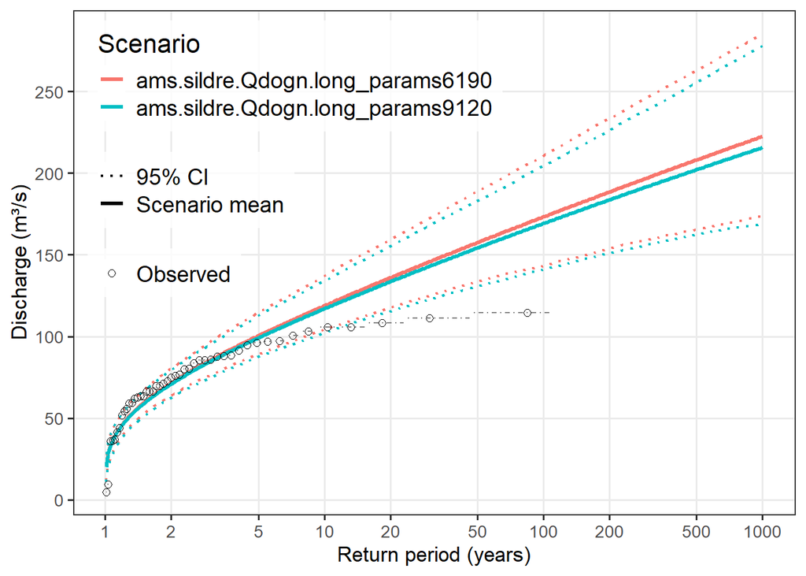

```r
plot.quantile.curves.gg(analyses,labels = names(analyses),show.pp.uncertainty = TRUE)
```

## 5.3 Optional: import of hydra2/Flomanalyse results (for comparison)

```r
if(file.exists(flomanalyse.quantiles.6190)){
    d<-fx.read.hydra.quantiles(flomanalyse.quantiles.6190)
    fx.compact_dt(d,caption = "Quantiles from Flomanalyse/hydra2",fontsize = 12)
}  else {
    message(paste("hydra2 flomanalyse quantiles file\n[",
                  flomanalyse.quantiles.6190,
                  "]\nDoesnt exist. \nDo an analysis in hydra2 if you want to compare"))
}
```

```
 [1] 1.000 0.965 1.266 1.467 1.660 1.916 2.110 2.310 2.584 2.799
```

**Quantiles from Flomanalyse/hydra2**

|  | Name | Post.mean | Lower | Upper | Relative |
| --- | --- | --- | --- | --- | --- |
| 1 | Mean | 77.1 | 77.1 | 77.100 | 1.000 |
| 2 | 2 | 74.4 | 68.0 | 81.700 | 0.965 |
| 3 | 5 | 97.6 | 88.1 | 108.440 | 1.267 |
| 4 | 10 | 113.1 | 101.0 | 126.990 | 1.467 |
| 5 | 20 | 128.0 | 112.5 | 145.820 | 1.661 |
| 6 | 50 | 147.7 | 126.4 | 171.580 | 1.916 |
| 7 | 100 | 162.7 | 136.4 | 190.700 | 2.111 |
| 8 | 200 | 178.1 | 145.4 | 211.030 | 2.310 |
| 9 | 500 | 199.2 | 156.2 | 236.850 | 2.584 |
| 10 | 1000 | 215.8 | 164.5 | 260.460 | 2.800 |

## 5.4 Optional: Update scenario list and results list to add Flomanalyse result

```r
if(file.exists(flomanalyse.quantiles.6190)){
    results$flomanalyse<-list(table=d,
                          analysis = list(ams=results$ams.hydra_params6190$ams))
#print(str(results,3))
#print(results$analysis$ams)
scenarios.df2<-rbind(scenarios.df,
                    data.frame(scenario = "flomanalyse",ams_path=NA, klima_path=NA,new.reg.coef=FALSE)
                    )
} else{
  scenarios.df2<-scenarios.df
}
scenarios.df2<-scenarios.df2[,c(1,4)]
fx.compact_dt(scenarios.df2,caption = "Updated Scenarios (incl Quantiles from Flomanalyse/hydra2)",fontsize = 12)
```

**Updated Scenarios (incl Quantiles from Flomanalyse/hydra2)**

|  | scenario | new.reg.coef |
| --- | --- | --- |
| 1 | ams.sildre.Qdogn.long_params6190 | False |
| 2 | ams.sildre.Qdogn.long_params9120 | True |
| 3 | flomanalyse | False |

## 5.5 Compare

```r
print(scenarios.df2)
```

```
                          scenario new.reg.coef
1 ams.sildre.Qdogn.long_params6190        FALSE
2 ams.sildre.Qdogn.long_params9120         TRUE
3                      flomanalyse        FALSE
```

```r
#tep 1 — Assign a unique color to each scenario
#my_colors <-RColorBrewer::brewer.pal(nrow(scenarios.df2), "Set3"),
my_colors <- c(
  "#cce5ff",  # light blue
  "#ffcccc",  # light red
  "#e6ffe6",  # light green
  "#fff0b3"   # light yellow
)
scenario_colors <- setNames(
  my_colors,
  scenarios.df2$scenario
)
#Build your scenario pairs
#pairs <- combn(seq_len(nrow(scenarios.df2)), 2, simplify = FALSE)
pairs<- list(c(1,2),c(1,3))
#loop
out.widgets <- lapply(pairs, function(p) {

  scA <- scenarios.df2$scenario[p[1]]
  scB <- scenarios.df2$scenario[p[2]]

   widget<-compare.two.quantile.tables.sidebyside (
    scenarioA = scA,
    scenarioB = scB,
    scenarios.df = scenarios.df2,
    results = results,
    bgA = scenario_colors[scA],
    bgB = scenario_colors[scB]
  )
    # Wrap widget with spacing
    htmltools::div(style="margin-bottom: 40px;", widget)
})

# Display all results
#htmltools::tagList(out[[1]]);htmltools::tagList(out[[2]])
do.call(htmltools::tagList, out.widgets)
```

**ams.sildre.Qdogn.long_params6190**

|  | Name | Post.mean | Lower | Upper | Relative |
| --- | --- | --- | --- | --- | --- |
| 1 | Mean | 76.28 | 68.10 | 86.14 | 1.000 |
| 2 | T2 | 71.65 | 63.89 | 80.47 | 0.939 |
| 3 | T5 | 100.46 | 89.15 | 114.71 | 1.317 |
| 4 | T10 | 118.84 | 104.25 | 137.09 | 1.558 |
| 5 | T20 | 136.00 | 117.76 | 159.32 | 1.783 |
| 6 | T50 | 157.55 | 133.68 | 189.05 | 2.065 |
| 7 | T100 | 173.24 | 143.33 | 210.71 | 2.271 |
| 8 | T200 | 188.51 | 153.85 | 233.64 | 2.471 |
| 9 | T500 | 208.12 | 165.55 | 262.79 | 2.728 |
| 10 | T1000 | 222.56 | 173.69 | 285.69 | 2.918 |

**ams.sildre.Qdogn.long_params9120**

|  | Name | Post.mean | Lower | Upper | Relative |
| --- | --- | --- | --- | --- | --- |
| 1 | Mean | 75.32 | 66.45 | 85.23 | 1.000 |
| 2 | T2 | 70.92 | 62.61 | 79.58 | 0.942 |
| 3 | T5 | 99.12 | 87.65 | 112.79 | 1.316 |
| 4 | T10 | 116.99 | 102.26 | 134.11 | 1.553 |
| 5 | T20 | 133.56 | 115.54 | 155.21 | 1.773 |
| 6 | T50 | 154.25 | 130.79 | 183.10 | 2.048 |
| 7 | T100 | 169.22 | 141.05 | 204.54 | 2.247 |
| 8 | T200 | 183.71 | 151.08 | 226.27 | 2.439 |
| 9 | T500 | 202.20 | 162.40 | 255.60 | 2.685 |
| 10 | T1000 | 215.74 | 168.88 | 277.91 | 2.864 |

**ams.sildre.Qdogn.long_params6190**

|  | Name | Post.mean | Lower | Upper | Relative |
| --- | --- | --- | --- | --- | --- |
| 1 | Mean | 76.28 | 68.10 | 86.14 | 1.000 |
| 2 | T2 | 71.65 | 63.89 | 80.47 | 0.939 |
| 3 | T5 | 100.46 | 89.15 | 114.71 | 1.317 |
| 4 | T10 | 118.84 | 104.25 | 137.09 | 1.558 |
| 5 | T20 | 136.00 | 117.76 | 159.32 | 1.783 |
| 6 | T50 | 157.55 | 133.68 | 189.05 | 2.065 |
| 7 | T100 | 173.24 | 143.33 | 210.71 | 2.271 |
| 8 | T200 | 188.51 | 153.85 | 233.64 | 2.471 |
| 9 | T500 | 208.12 | 165.55 | 262.79 | 2.728 |
| 10 | T1000 | 222.56 | 173.69 | 285.69 | 2.918 |

**flomanalyse**

|  | Name | Post.mean | Lower | Upper | Relative |
| --- | --- | --- | --- | --- | --- |
| 1 | Mean | 77.1 | 77.1 | 77.100 | 1.000 |
| 2 | 2 | 74.4 | 68.0 | 81.700 | 0.965 |
| 3 | 5 | 97.6 | 88.1 | 108.440 | 1.267 |
| 4 | 10 | 113.1 | 101.0 | 126.990 | 1.467 |
| 5 | 20 | 128.0 | 112.5 | 145.820 | 1.661 |
| 6 | 50 | 147.7 | 126.4 | 171.580 | 1.916 |
| 7 | 100 | 162.7 | 136.4 | 190.700 | 2.111 |
| 8 | 200 | 178.1 | 145.4 | 211.030 | 2.310 |
| 9 | 500 | 199.2 | 156.2 | 236.850 | 2.584 |
| 10 | 1000 | 215.8 | 164.5 | 260.460 | 2.800 |

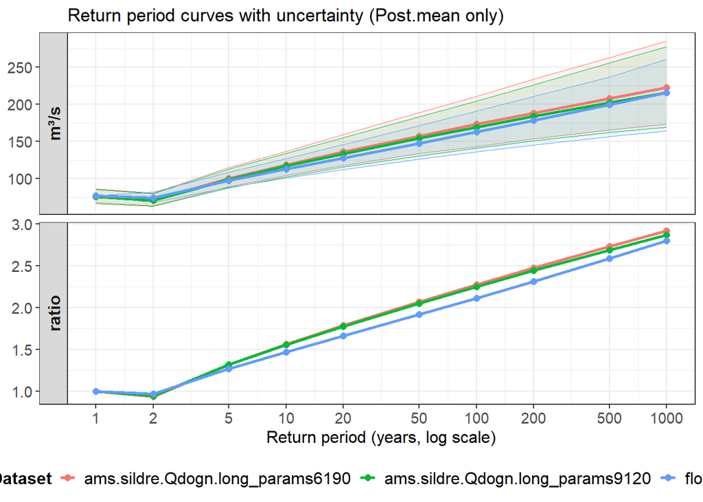

```r
fx.compare.all.quantile.tables.by.plot (results)
```